# Text Analysis on 3 Things Canada

Paula Jennings

March 12, 2018

## 3 Things Text Study

Based on Julia Silge’s log on text mining. The intent is to extract some information from 3 Things tweets so we can learn more about them.

```r
tweets <- read.csv("D:/CivicTechYYC/3thingsforcanada3.csv",stringsAsFactors = FALSE)
```

## Start with distribution plots

The first get to know the data takes form in plots.

There was an extraction done over 2017 especially since we wanted to capitalize over the Canada 150 celebration. From a count of tweets binned by the tweet timestamp, we can see that enthusiasm was greater for the first part of the year and around Canada’s birthday we see a grouping of high activity.

```r
library(lubridate)
```

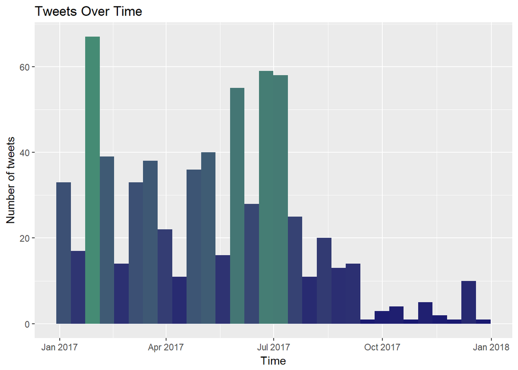

```r
library(ggplot2)
library(scales)

tweets$timestamp <- ymd_hms(tweets$timestamp)
ggplot(data = tweets, aes(x = timestamp)) +
  geom_histogram(aes(fill = ..count..)) +
  theme(legend.position = "none") +
  xlab("Time") + ylab("Number of tweets") + ggtitle("Tweets Over Time") +
  scale_fill_gradient(low = "midnightblue", high = "aquamarine4")
```

## Patterns over different ranges

Plotting number of tweets by month definitely shows a high right before Canada’s birthday which is expected. Tweets seem to build durning the week with the highest tweet count on Friday and lowest on Saturday and Sunday. It seems like there is more tweeting when people work? Time of tweets might help us here.

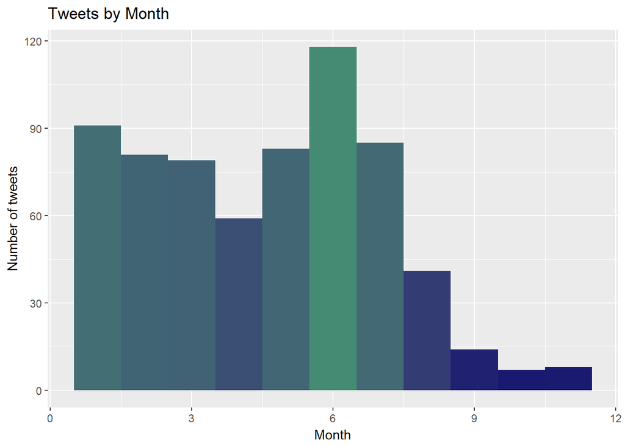

```r
ggplot(data = tweets, aes(x = month(timestamp))) +
  geom_histogram(breaks = seq(.5,12, by=1), aes(fill = ..count..)) +
  theme(legend.position = "none") +
  xlab("Month") + ylab("Number of tweets") + ggtitle("Tweets by Month") +
  scale_fill_gradient(low = "midnightblue", high = "aquamarine4")
```

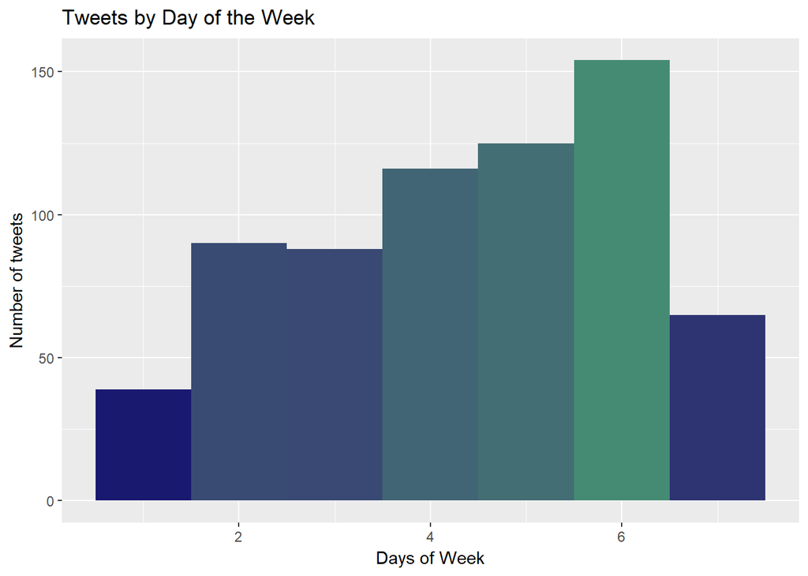

```r
ggplot(data = tweets, aes(x = wday(timestamp))) +
  geom_histogram(breaks = seq(.5, 7.5, by=1), aes(fill = ..count..)) +
  theme(legend.position = "none") +
  xlab("Days of Week") + ylab("Number of tweets") + ggtitle("Tweets by Day of the Week") +
  scale_fill_gradient(low = "midnightblue", high = "aquamarine4")
```

## Measuring consistency of week patterns.

```r
chisq.test(table(wday(tweets$timestamp, label = TRUE)))
```

```
##
##  Chi-squared test for given probabilities
##
## data:  table(wday(tweets$timestamp, label = TRUE))
## X-squared = 92.142, df = 6, p-value < 2.2e-16
```

```r
x3table <- table(wday(tweets$timestamp, label = TRUE))
mean(x3table[c(2:5)]/mean(x3table[c(1,6,7)]))
```

```
## [1] 1.218023
```

```r
chisq.test(table(wday(tweets$timestamp, label = TRUE)), p = c(4, 5, 5, 5, 5, 4, 4)/32)
```

```
##
##  Chi-squared test for given probabilities
##
## data:  table(wday(tweets$timestamp, label = TRUE))
## X-squared = 95.845, df = 6, p-value < 2.2e-16
```

```r
tweets$timeonly <- as.numeric(tweets$timestamp - trunc(tweets$timestamp, "days"))
tweets[(minute(tweets$timestamp) == 0 & second(tweets$timestamp) == 0),11] <- NA
mean(is.na(tweets$timeonly))
```

```
## [1] 0
```

## Time of tweets

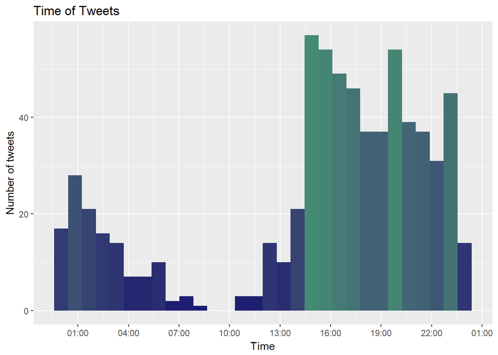

```r
class(tweets$timeonly) <- "POSIXct"
ggplot(data = tweets, aes(x = timeonly)) +
  geom_histogram(aes(fill = ..count..)) +
  theme(legend.position = "none") +
  xlab("Time") + ylab("Number of tweets") + ggtitle("Time of Tweets") +
  scale_x_datetime(breaks = date_breaks("3 hours"),
                   labels = date_format("%H:00")) +
  scale_fill_gradient(low = "midnightblue", high = "aquamarine4")
```

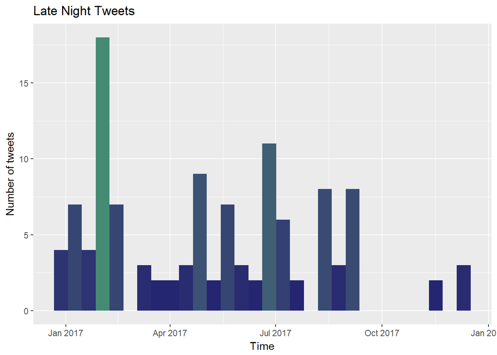

```r
latenighttweets <- tweets[(hour(tweets$timestamp) < 6),]
ggplot(data = latenighttweets, aes(x = timestamp)) +
  geom_histogram(aes(fill = ..count..)) +
  theme(legend.position = "none") +
  xlab("Time") + ylab("Number of tweets") + ggtitle("Late Night Tweets") +
  scale_fill_gradient(low = "midnightblue", high = "aquamarine4")
```

## Hastags

Typically all have hashtags, which is expected since we are at least expecting the #3thingsforcanada or something similar as a mark. There are a few that appear not to have one and I am assuming they are replies but this can be noted and checked, if needed, later.

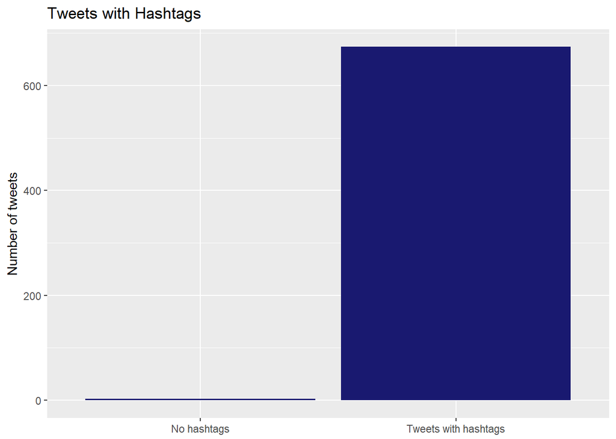

```r
ggplot(tweets, aes(factor(grepl("#", tweets$text)))) +
  geom_bar(fill = "midnightblue") +
  theme(legend.position="none", axis.title.x = element_blank()) +
  ylab("Number of tweets") +
  ggtitle("Tweets with Hashtags") +
  scale_x_discrete(labels=c("No hashtags", "Tweets with hashtags"))
```

## Replies, Retweets and Tweets

There are approximately as many retweets as tweets and there are very few replies.

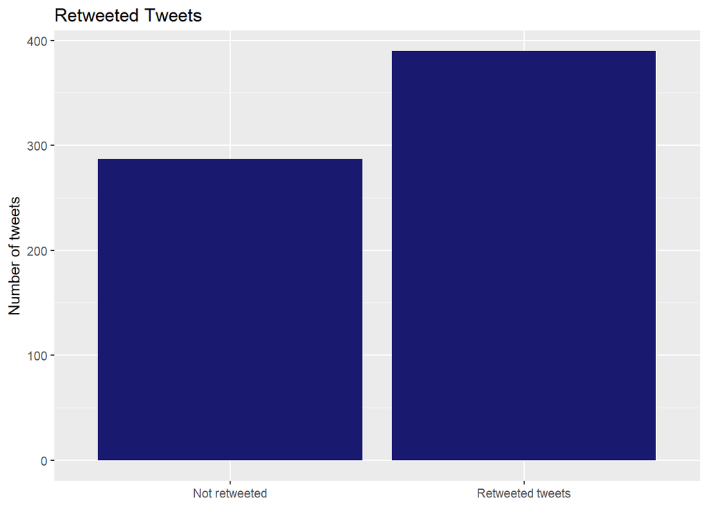

```r
ggplot(tweets, aes(factor(tweets$retweets != 0))) +
  geom_bar(fill = "midnightblue") +
  theme(legend.position="none", axis.title.x = element_blank()) +
  ylab("Number of tweets") +
  ggtitle("Retweeted Tweets") +
  scale_x_discrete(labels=c("Not retweeted", "Retweeted tweets"))
```

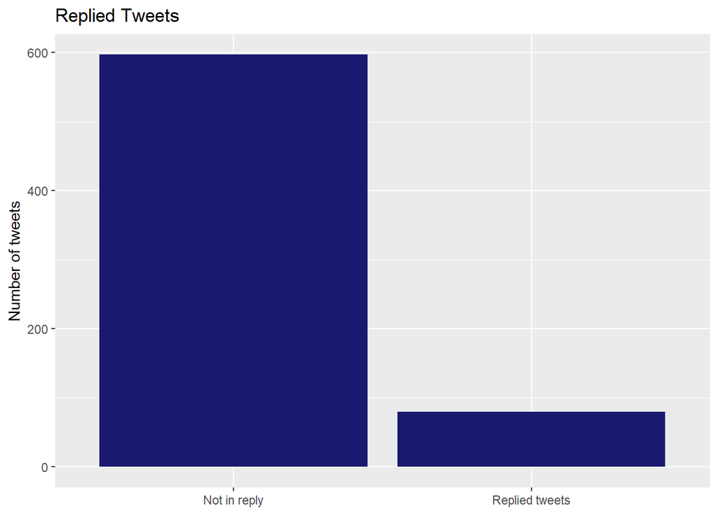

```r
ggplot(tweets, aes(factor(tweets$replies != 0))) +
  geom_bar(fill = "midnightblue") +
  theme(legend.position="none", axis.title.x = element_blank()) +
  ylab("Number of tweets") +
  ggtitle("Replied Tweets") +
  scale_x_discrete(labels=c("Not in reply", "Replied tweets"))
```

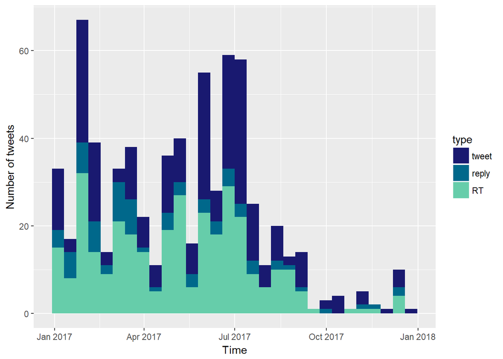

```r
tweets$type <- "tweet"
tweets[(tweets$retweets > 0), c("type")] <- "RT"
tweets[(tweets$replies > 0),c("type")] <- "reply"
tweets$type <- as.factor(tweets$type)
tweets$type = factor(tweets$type,levels(tweets$type)[c(3,1,2)])

ggplot(data = tweets, aes(x = timestamp, fill = type)) +
  geom_histogram() +
  xlab("Time") + ylab("Number of tweets") +
  scale_fill_manual(values = c("midnightblue", "deepskyblue4", "aquamarine3"))
```